# exDE

October 11, 2023

`~/exDE/exDE.Rmd`

## $\odot$

`exDE` is a software package that implements a mathematical framework for modular computation with structural flexibility for malaria and other mosquito-borne pathogens, as described in *Spatial Dynamics of Malaria Transmission* [1].

`Intro` – What is exDE?

`Forcing` – `exDE` has various ways of implementing forcing.

$\dagger$ – document information, including references

## Design & Features

### $\oplus$

`exDE` is a software package, developed by Sean L Wu and David L Smith, that implements modular computation for malaria and other mosquito-borne pathogens [1]. The library of dynamical components includes a large library of previously published models and algorithms. The mathematical framework was designed to be structurally flexible to facilitate nimble model building and the construction of ensembles with scalable complexity.

### Epidemiology

#### $\oplus$

- `Xpar`
- `Exposure` – in `exDE` the process of exposure and infection is handled as a generalized function that computes the FoI by strata as a function of the local EIR by strata and exposure to malaria while traveling
- `Dynamics` – general features of $d{\cal X}/dt$
- `Cohorts` – solving the dynamics of infection and immunity in cohorts of humans
- `Stratification` – the utilities established for principled stratification

#### Xpar

#### Exposure

- Exposure and infection is handled by `Exposure` (in `exposure.R`) in steps:
  - the model computes a local EIR and passes it to `Exposure`
  - Exposure calls `F_b` to get a measure of the probability of infection, per infective bite, so the *expected* number of infective bites is $b E$. The model `F_b` is dispatched by `Xpar`
  - the expected number of infective bites is transformed into a measure of the stratum specific local FoI, depending on the model for Environmental Heterogeneity
  - the travel FoI is added to the local FoI

#### Dynamics

#### Cohorts

- `xde_setup_human` vs `xde_setup_cohort`

#### Stratification

- principled stratification

### Spatial Dynamics

### Mosquito Ecology

### Vector Control

Vector Control in `exDE` is implemented through a set of linked functions:

- **Distribution** of commodities is handled through the function family called `VectorControl`
- **Coverage** and the decay of efficacy (*e.g.* waning efficacy of insecticides, ownsership and condition of nets)
- **Human Behavior** - dependent effects (*e.g.* bed net use)
- **Effects** - we compute something like coverage and its *effects* on various parameters or variables (*e.g.* resource availability) in models that compute *integrated* effects
- **Effect Sizes** - modifies parameters after a call to `Bionomics` introducing independent effect sizes that modify the parameters.

### Forcing

`exDE` has a large set of built-in functions to describe exogenous forcing.

By default, exogenous forcing is turned off.

The list objects defining various kinds of forcing are in a nested hierarchy with several classes of base functions:

- **Malaria Importation** is handled through travel and visitors.
- **Abiotic** forcing by weather and hydrology
- **Civil** factors, including shocks and economic development
- **Malaria Control** of all sorts
- **Resources** for mosquitoes can be dynamically changing, affecting the availability of aquatic habitats, blood, sugar, and resting sites.

If the class of a list object is `null` then there is no need to define anything of the objects it might contain. If a nested `list` objects is defined, then the list that contains it is turned on and set to `forced.` See Forcing for details.

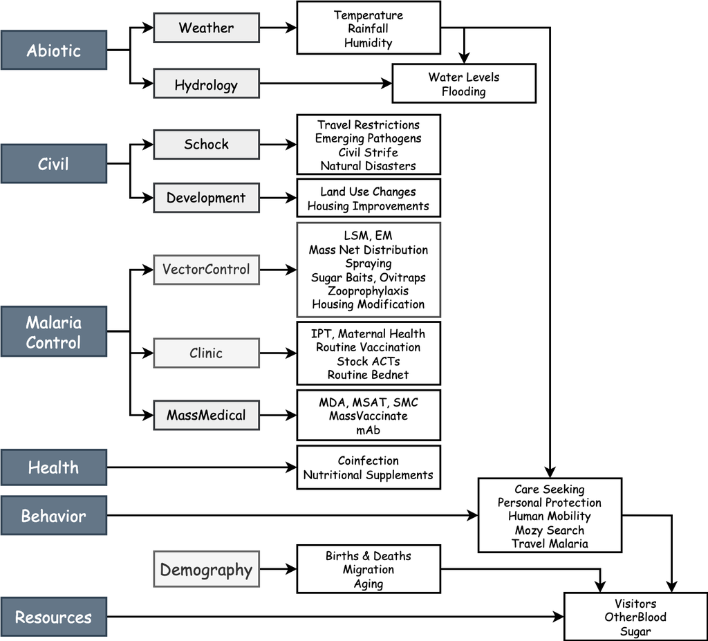

**Figure 1**

## Model Libraries

## $\boxplus$

## $\dagger$

**References**

Wu SL, Henry JM, Citron DT, Ssebuliba DM, Nsumba JN, C HMS, et al. Spatial dynamics of malaria transmission. PLOS Computational Biology. 2023;19: e1010684. doi:10.1371/journal.pcbi.1010684